# FIFA 2019 Analysis - Inbar Siloni

Inbar Siloni

18 1 2020

# Background

In this markdown, I analyze [this](https://www.kaggle.com/karangadiya/fifa19/download) data of fifa players.

## Goals

In my research, I will focus on two main questions:

- Is there a correlation between a player’s abilities, his age and his value?
- Do players score the same if they are right footed and left footed?

## importing the data set

# Transformation, Visualization, and Modelling

## doing some transformation

First, I did a little transformation for several variables.

```
## Observations: 425
## Variables: 45
## $ age                  <dbl> 31, 33, 26, 27, 27, 32, 31, 32, 28, 32, 27, 24...
## $ overall              <dbl> 94, 94, 92, 91, 91, 91, 91, 91, 90, 90, 89, 89...
## $ potential            <dbl> 94, 94, 93, 92, 91, 91, 91, 91, 90, 90, 90, 94...
## $ club                 <chr> "FC Barcelona", "Juventus", "Paris Saint-Germa...
## $ value                <chr> "€110.5M", "€77M", "€118.5M", "€102M", "€93M",...
## $ preferred_foot       <chr> "Left", "Right", "Right", "Right", "Right", "R...
## $ position             <chr> "RF", "ST", "LW", "RCM", "LF", "RCM", "RS", "R...
## $ crossing             <dbl> 84, 84, 79, 93, 81, 86, 77, 66, 88, 84, 68, 82...
## $ finishing            <dbl> 95, 94, 87, 82, 84, 72, 93, 60, 76, 76, 65, 84...
## $ heading_accuracy     <dbl> 70, 89, 62, 55, 61, 55, 77, 91, 54, 54, 54, 68...
## $ short_passing        <dbl> 90, 81, 84, 92, 89, 93, 82, 78, 92, 93, 86, 87...
## $ volleys              <dbl> 86, 87, 84, 82, 80, 76, 88, 66, 82, 82, 56, 88...
## $ dribbling            <dbl> 97, 88, 96, 86, 95, 90, 87, 63, 81, 89, 79, 92...
```

[output cut: 32 more lines]

## doing some visualization

```r
 fifa_data %>%
  group_by(club) %>%
  summarize()
```

```
## # A tibble: 14 x 1
##    club
##    <chr>
##  1 Atalanta
##  2 Borussia Dortmund
##  3 Chelsea
##  4 FC Barcelona
##  5 Juventus
##  6 Liverpool
##  7 Manchester City
##  8 Napoli
##  9 Olympique Lyonnais
## 10 Paris Saint-Germain
## 11 RB Leipzig
## 12 Real Madrid
## 13 Tottenham Hotspur
## 14 Valencia CF
```

Now let’s take a look at the age distribution of the players:

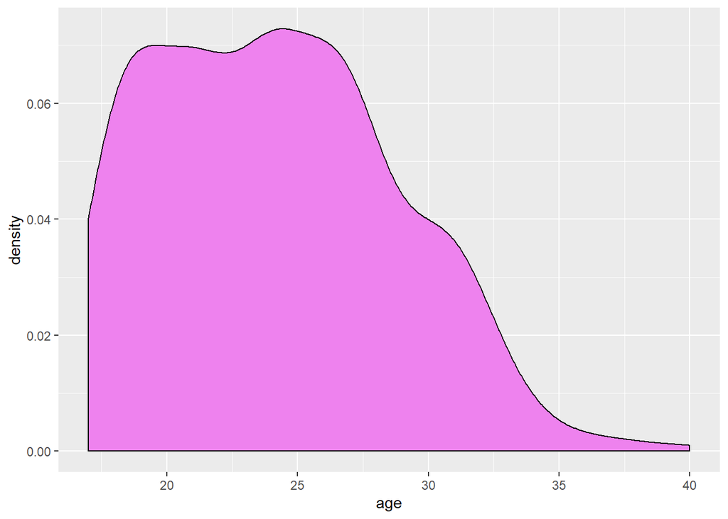

```r
ggplot(data=fifa_data, aes(x=age))+
  geom_density(fill="violet")
```

```r
fifa_data %>%
  summarise(
    min = min(age),
    median = median(age),
    max = max(age)
  )
```

```
## # A tibble: 1 x 3
##     min median   max
##   <dbl>  <dbl> <dbl>
## 1    17     24    40
```

```r
fifa_data %>%
  group_by(age_group) %>%
  count()
```

```
## # A tibble: 5 x 2
## # Groups:   age_group [5]
##   age_group        n
##   <chr>        <int>
## 1 20 and under   107
## 2 21 to 25       154
## 3 25 to 30       117
## 4 31 to 35        43
## 5 Over 35          4
```

We can see that most of the players are under the age of 30 and over the age of 20. The biggest group age is 21 to 25.

Let’s see how their value is distributed:

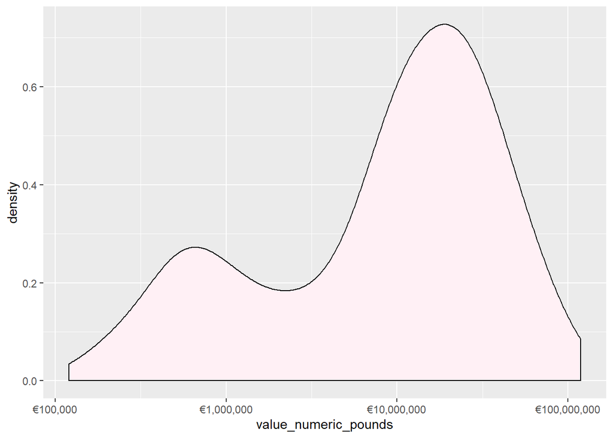

```r
ggplot(data=fifa_data, aes(x=value_numeric_pounds))+
  geom_density(fill="lavenderblush")+
  scale_x_log10(labels = dollar_format(prefix = "€"))
```

So, as we can see there are two “humps” is this distribution. A possible explanation to this is the difference of values for the squad players (those who play in the league, for example) and players in the club’s teen groups and substitutes to substitutes. Both players’ types values distribute normally, but most of the subs are valued at max as the min for squad players.

## modelling

Let’s get down to business.

First, we will check if there is a correlation between preferred foot and scoring:

```r
fit1<-lm(formula = finishing~preferred_foot, data= fifa_data)
summary(fit1)
```

```
##
## Call:
## lm(formula = finishing ~ preferred_foot, data = fifa_data)
##
## Residuals:
##     Min      1Q  Median      3Q     Max
## -46.186 -15.821   4.179  18.179  42.179
##
## Coefficients:
##                     Estimate Std. Error t value Pr(>|t|)
## (Intercept)           56.186      2.129  26.386   <2e-16 ***
## preferred_footRight   -4.365      2.485  -1.757   0.0797 .
## ---
## Signif. codes:  0 '***' 0.001 '**' 0.01 '*' 0.05 '.' 0.1 ' ' 1
##
## Residual standard error: 22.64 on 423 degrees of freedom
## Multiple R-squared:  0.007241,   Adjusted R-squared:  0.004894
## F-statistic: 3.085 on 1 and 423 DF,  p-value: 0.07972
```

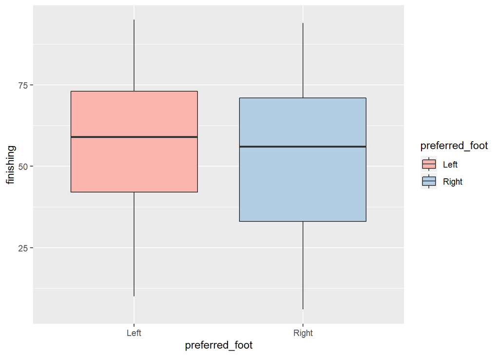

```r
fifa_data %>%
  ggplot(aes(x = preferred_foot, y = finishing,
           fill = preferred_foot))+
  geom_boxplot()+
  scale_fill_brewer(palette = "Pastel1")
```

```r
t.test(fifa_data$finishing~fifa_data$preferred_foot)
```

```
##
##  Welch Two Sample t-test
##
## data:  fifa_data$finishing by fifa_data$preferred_foot
## t = 1.8655, df = 223.86, p-value = 0.06342
## alternative hypothesis: true difference in means is not equal to 0
## 95 percent confidence interval:
##  -0.2460069  8.9766627
## sample estimates:
##  mean in group Left mean in group Right
##            56.18584            51.82051
```

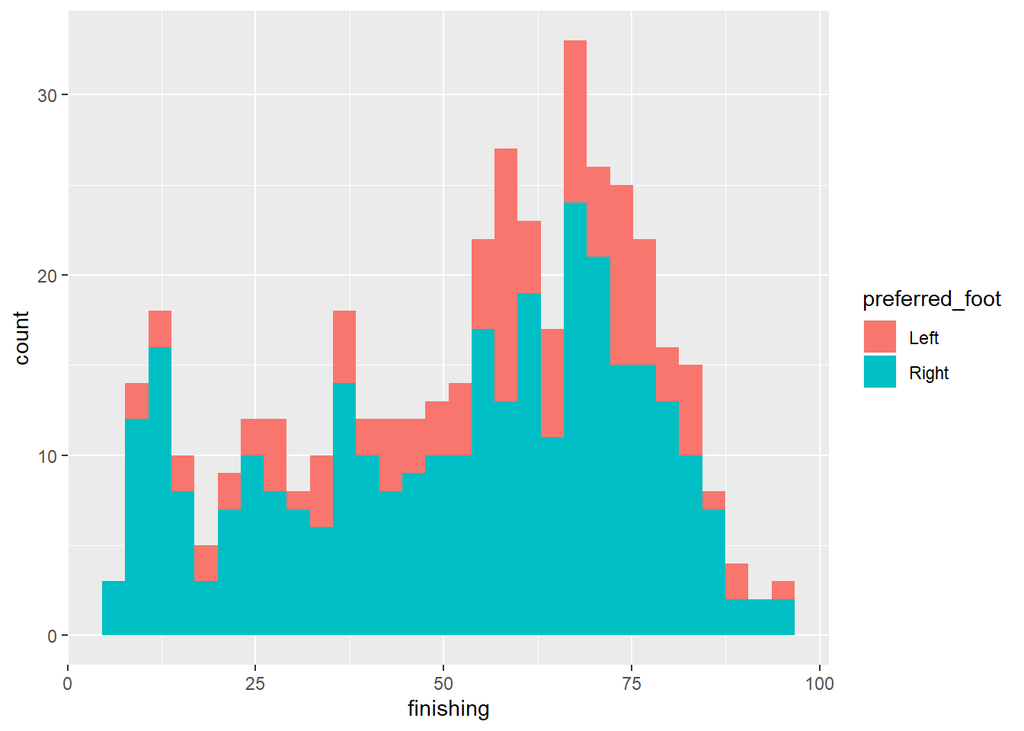

```r
fifa_data %>%
  ggplot(aes(x = finishing,
           fill = preferred_foot))+
  geom_histogram()
```

Now to the next research question- let’s see if there is a correlation between abilities, age and value!

First, let’s take a look at age vs. value:

```r
fit2<-lm(formula = log1p(value_numeric_pounds)~age_group, data= fifa_data)
summary(fit2)
```

```
##
## Call:
## lm(formula = log1p(value_numeric_pounds) ~ age_group, data = fifa_data)
##
## Residuals:
##     Min      1Q  Median      3Q     Max
## -4.6701 -0.6754  0.1232  0.8174  4.1121
##
## Coefficients:
##                   Estimate Std. Error t value Pr(>|t|)
## (Intercept)       14.09783    0.11564 121.912   <2e-16 ***
## age_group21 to 25  2.13899    0.15054  14.208   <2e-16 ***
## age_group25 to 30  2.67296    0.16001  16.705   <2e-16 ***
## age_group31 to 35  2.62457    0.21598  12.152   <2e-16 ***
## age_groupOver 35   0.03287    0.60917   0.054    0.957
## ---
## Signif. codes:  0 '***' 0.001 '**' 0.01 '*' 0.05 '.' 0.1 ' ' 1
##
## Residual standard error: 1.196 on 420 degrees of freedom
## Multiple R-squared:  0.4517, Adjusted R-squared:  0.4465
## F-statistic: 86.49 on 4 and 420 DF,  p-value: < 2.2e-16
```

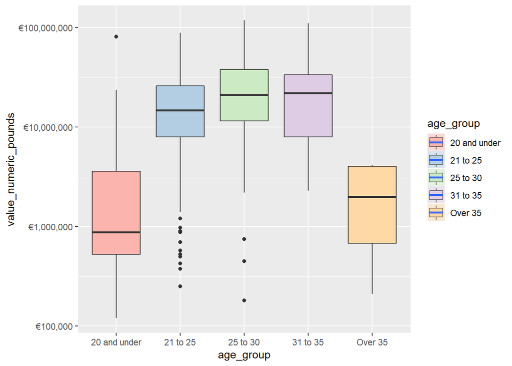

```r
fifa_data %>%
  ggplot(aes(x=age_group, y=value_numeric_pounds, fill=age_group))+
  geom_boxplot()+
  scale_y_log10(labels = dollar_format(prefix = "€"))+
  stat_smooth(method = "lm")+
  scale_fill_brewer(palette = "Pastel1")
```

From the regression and chart we can see that players aged 21-35 earn more, and more specifically in age group 25-30. This supports my explanation to the “humps” in the value distribution chart.

Let’s see the correlation for different abilities:

So, obviously, field players require different abilities than goal keepers. We will check the correlation for all players and for each group individually.

Here we check for all players:

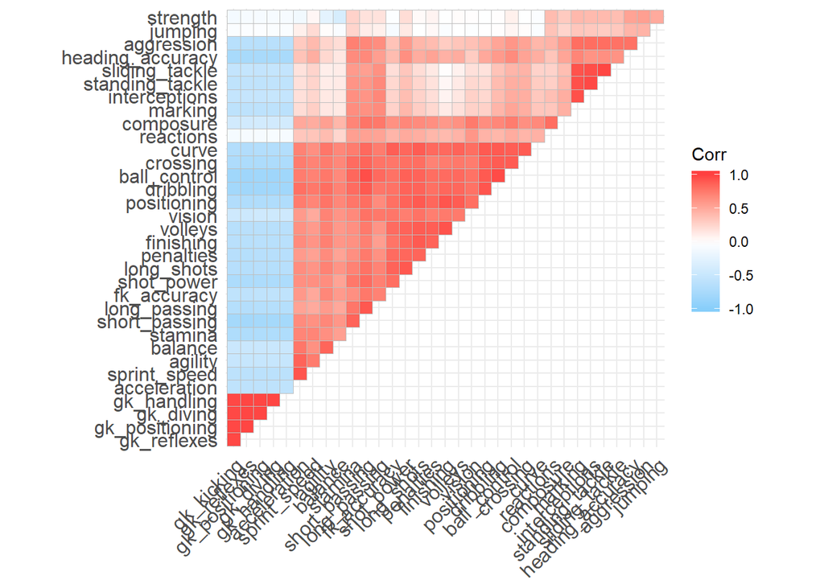

```r
abilities <- fifa_data %>% select(crossing:gk_reflexes)
ability_corr <- cor(abilities)
ggcorrplot(ability_corr, type = "upper", hc.order = T, hc.method = "complete",
           colors = c("lightskyblue","white","brown1"))
```

We see that some abilities are correlated with others, and some aren’t. Let’s see if we can explain this. Here we check just for field players:

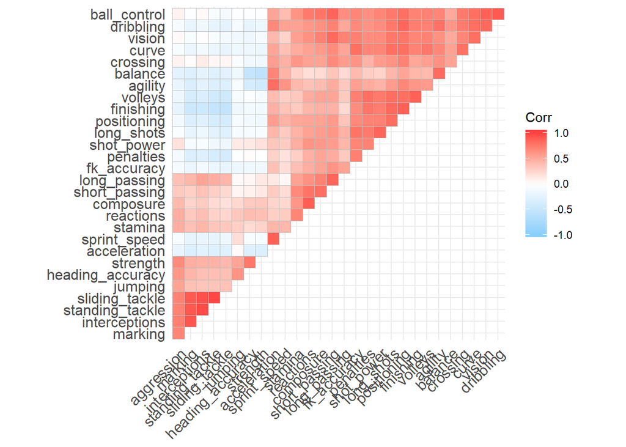

```r
abilities <- fifa_data %>% filter(!position == "GK") %>% select(crossing:sliding_tackle)
ability_corr <- cor(abilities)
ggcorrplot(ability_corr, type = "upper", hc.order = T, hc.method = "complete",
           colors = c("lightskyblue","white","brown1"))
```

Once again we see a very strong correlation of some abilities while others don’t correlate at all. The reason for this can be that abilities like short passing and long passing must be related to the same physical abilities, while agility and jumping do not. Overall we learn that most of the abilities are correlated to one another. And here we check just for goal keepers:

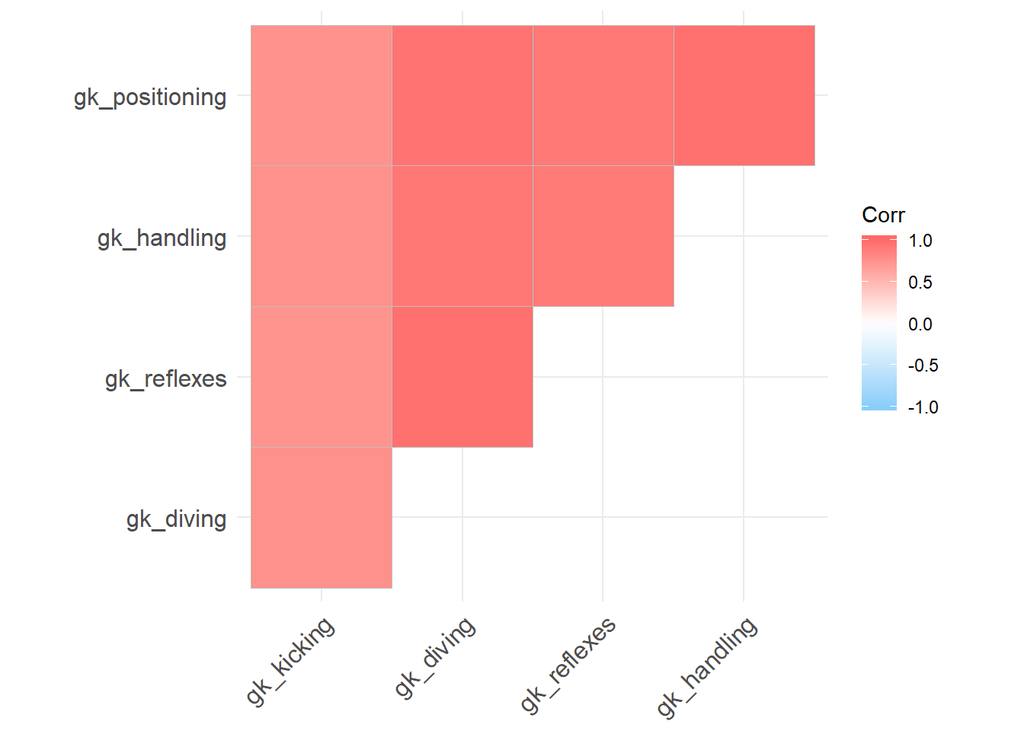

```r
abilities <- fifa_data %>% filter(position == "GK") %>% select(gk_diving:gk_reflexes)
ability_corr <- cor(abilities)
ggcorrplot(ability_corr, type = "upper", hc.order = T, hc.method = "complete",
          colors = c("lightskyblue","white","indianred1"))
```

for goal keepers the situation is different. Since their abilities are measured only for, well, goal keeping, it makes sense that all the abilities will be correlated. Still we see that kicking is not as correlated as the other abilities, which makes sense because it relates to foot ability and not body ability (the others are related mostly to hands).

Now that we have established the relation between different abilities, let’s see if there is a correlation between the value of a player and his abilities:

```r
fit6<-lm(formula = log1p(value_numeric_pounds) ~ overall, data = fifa_data)
summary(fit6)
```

```
##
## Call:
## lm(formula = log1p(value_numeric_pounds) ~ overall, data = fifa_data)
##
## Residuals:
##      Min       1Q   Median       3Q      Max
## -2.81867 -0.14579  0.04936  0.22733  0.71434
##
## Coefficients:
##             Estimate Std. Error t value Pr(>|t|)
## (Intercept)  2.25991    0.16632   13.59   <2e-16 ***
## overall      0.17797    0.00216   82.39   <2e-16 ***
## ---
## Signif. codes:  0 '***' 0.001 '**' 0.01 '*' 0.05 '.' 0.1 ' ' 1
##
## Residual standard error: 0.3899 on 423 degrees of freedom
## Multiple R-squared:  0.9413, Adjusted R-squared:  0.9412
## F-statistic:  6788 on 1 and 423 DF,  p-value: < 2.2e-16
```

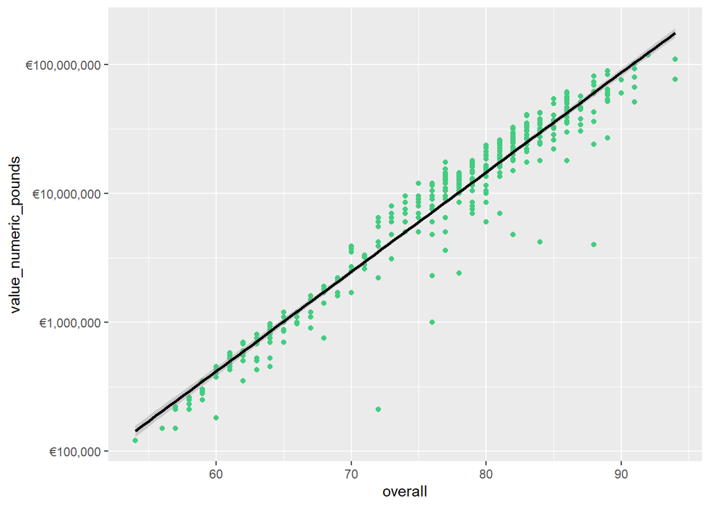

```r
fifa_data %>%
  ggplot(aes(y=value_numeric_pounds, x= overall))+
  geom_point(color="seagreen3")+
  scale_y_log10(labels = dollar_format(prefix = "€"))+
  stat_smooth(method = "lm",color="black")
```

We see there definitely is a correlation! The p-value is very small and the chart shows a strong connection. But does age matter?

Lets check if there is a correlation between abilities, value and age:

```r
fit <- lm(formula = log1p(value_numeric_pounds) ~ age_group+overall, data = fifa_data)
summary(fit)
```

```
##
## Call:
## lm(formula = log1p(value_numeric_pounds) ~ age_group + overall,
##     data = fifa_data)
##
## Residuals:
##      Min       1Q   Median       3Q      Max
## -0.91127 -0.11730  0.01927  0.12131  0.56513
##
## Coefficients:
##                    Estimate Std. Error t value Pr(>|t|)
## (Intercept)        0.929672   0.112529   8.262 1.91e-15 ***
## age_group21 to 25 -0.162438   0.032086  -5.063 6.20e-07 ***
## age_group25 to 30 -0.496666   0.038087 -13.040  < 2e-16 ***
## age_group31 to 35 -0.999342   0.047717 -20.943  < 2e-16 ***
## age_groupOver 35  -2.764897   0.106163 -26.044  < 2e-16 ***
## overall            0.199574   0.001679 118.847  < 2e-16 ***
## ---
## Signif. codes:  0 '***' 0.001 '**' 0.01 '*' 0.05 '.' 0.1 ' ' 1
##
## Residual standard error: 0.2033 on 419 degrees of freedom
## Multiple R-squared:  0.9842, Adjusted R-squared:  0.984
## F-statistic:  5221 on 5 and 419 DF,  p-value: < 2.2e-16
```

```r
fit.av <- aov(fit)
summary(fit.av)
```

```
##              Df Sum Sq Mean Sq F value Pr(>F)
## age_group     4  495.0   123.8    2995 <2e-16 ***
## overall       1  583.6   583.6   14125 <2e-16 ***
## Residuals   419   17.3     0.0
## ---
## Signif. codes:  0 '***' 0.001 '**' 0.01 '*' 0.05 '.' 0.1 ' ' 1
```

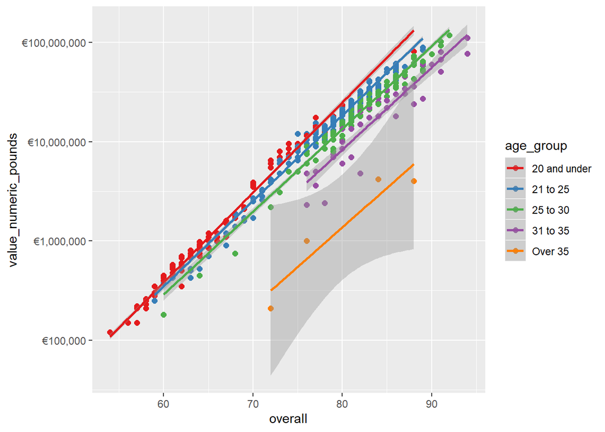

```r
fifa_data %>%
  ggplot(aes(y=value_numeric_pounds, x=overall,
             group = age_group,
             color = age_group))+
  geom_point(size = 2)+
  scale_y_log10(labels = dollar_format(prefix = "€"))+
  stat_smooth(method = "lm")+
  scale_color_brewer(palette = "Set1")
```

# conclusion

I checked two main questions-

*Is there a correlation between a player’s abilities, his age and his value?

*Do players score the same if they are right footed and left footed?

The first question showed a strong correlation between the three variables, but the second one did not. I have learned that it doesn’t matter if you are a leftie or a rightie, as long as you stay young and talented- football is the right place for you.

Also I really held myself back the entire project because I know I’m not supposed to show my opinions but Real Madrid are the best club in the world and my next project will show that they rule in every aspect.

Thank you for reading!